# STK39 in TCGA colorectal cancer (COAD + READ): expression, co-expression programs and survival

2026-10-17

## Data

UCSC Xena GDC hub (STAR gene counts, log2(count+1), back-transformed to counts; GDC clinical and OS tables). One primary tumor (`-01`) and/or one solid tissue normal (`-11`) sample per patient: **624 tumors, 51 normals**. Expression = TMM-normalised log2 CPM.

## 1. Tumor vs normal

Median STK39 log2CPM: tumor 6.29 vs normal 6.41; Wilcoxon p = 0.17. In 50 matched pairs the median tumor−normal difference was -0.0901 (paired Wilcoxon p = 0.0968; 54% of pairs lower in tumor). **No significant tumor/normal difference.**

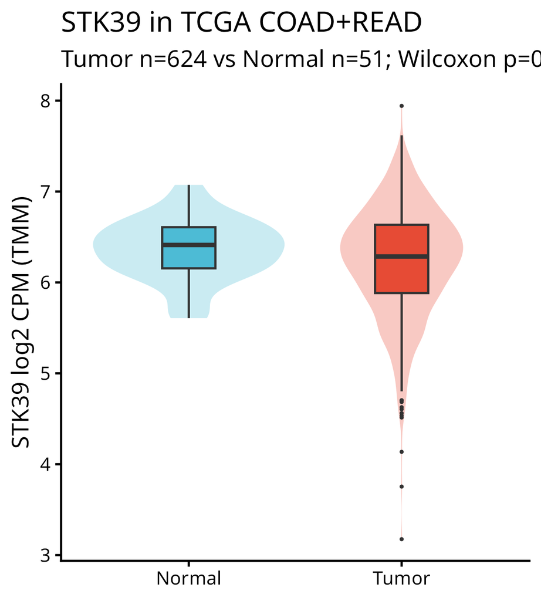

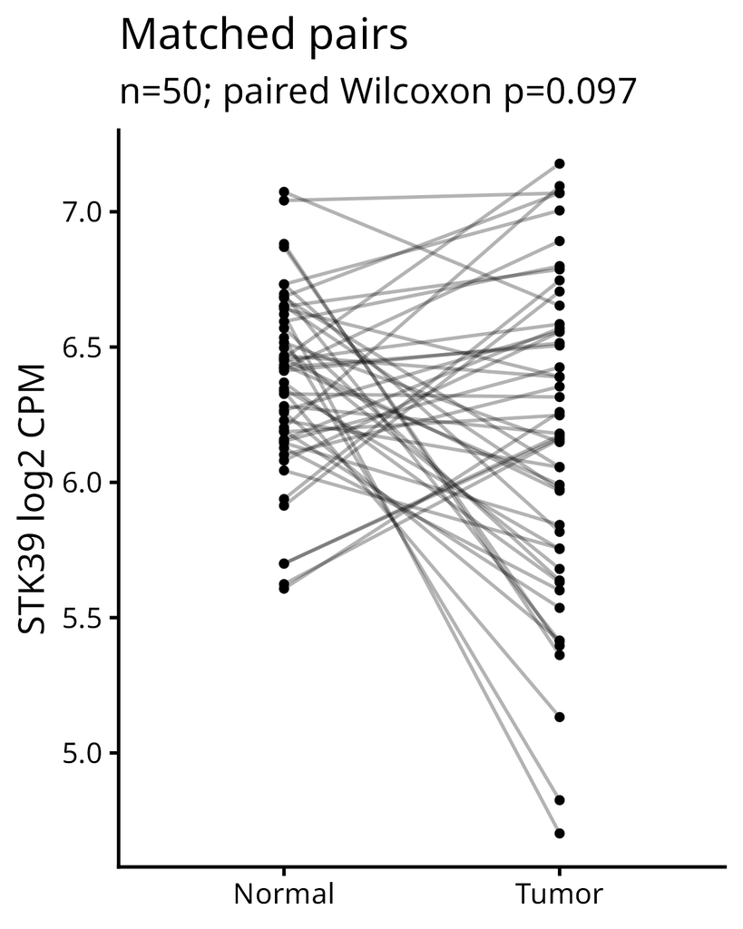

## 2. STK39-high vs STK39-low tumors (median split, limma-voom, adjusted for COAD/READ)

15805 protein-coding genes tested; 11012 had FDR < 0.05 (large n gives power for small shifts), but only **3 up / 130 down** passed FDR < 0.05 & |log2FC| > 1. Top down: LTC4S, TMEM121, MRPS24, MMP23B, GPS2, HDAC10, CCR10, CASTOR1, CAVIN3, FTH1. Up: ARHGEF35, EIF3CL, CLDN2.

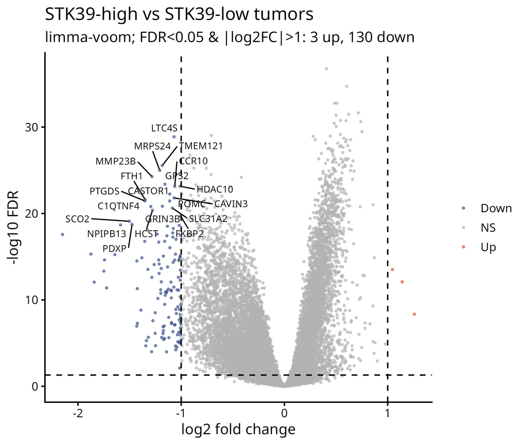

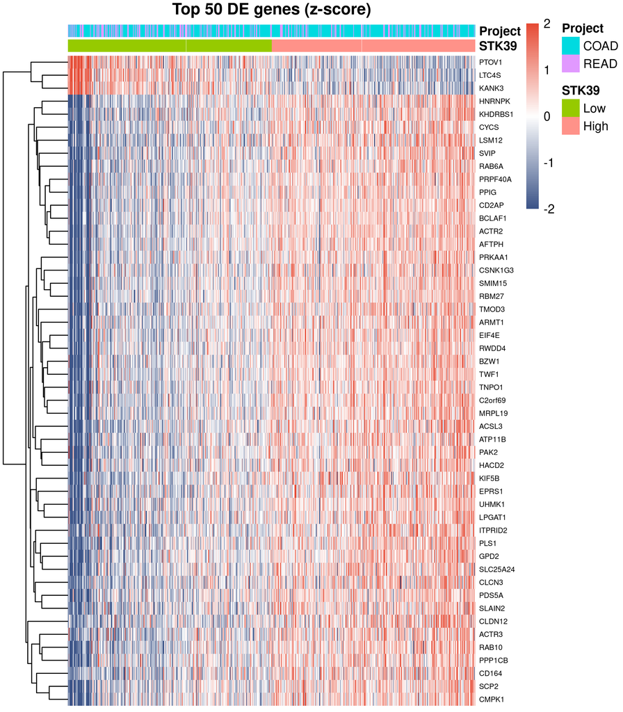

## 3. Enrichment

ORA (|log2FC|>1 genes): GO BP down = 0 terms, KEGG down = 2 (Nicotine addiction; Neuroactive ligand-receptor interaction); too few up genes for ORA. GSEA on the limma t-statistic: **591 GO BP** (349 positive / 242 negative) and **65 KEGG** pathways at FDR<0.05. STK39-high tumors are enriched for RNA processing, spliceosome, ER protein processing and cell cycle; STK39-low tumors for immune/inflammatory and neuroactive-ligand programs.

Top GSEA KEGG pathways

|  | Description | NES | p.adjust |
| --- | --- | --- | --- |
| hsa03013 | Nucleocytoplasmic transport | 2.3275 | 0.0000 |
| hsa04141 | Protein processing in endoplasmic reticulum | 2.2998 | 0.0000 |
| hsa04110 | Cell cycle | 2.2114 | 0.0000 |
| hsa03015 | mRNA surveillance pathway | 2.1077 | 0.0001 |
| hsa03018 | RNA degradation | 2.1014 | 0.0003 |
| hsa05150 | Staphylococcus aureus infection | -2.5352 | 0.0000 |
| hsa04080 | Neuroactive ligand-receptor interaction | -2.3854 | 0.0000 |
| hsa05310 | Asthma | -2.1901 | 0.0028 |
| hsa04061 | Viral protein interaction with cytokine and cytokine receptor | -2.1757 | 0.0000 |
| hsa05320 | Autoimmune thyroid disease | -2.1648 | 0.0005 |

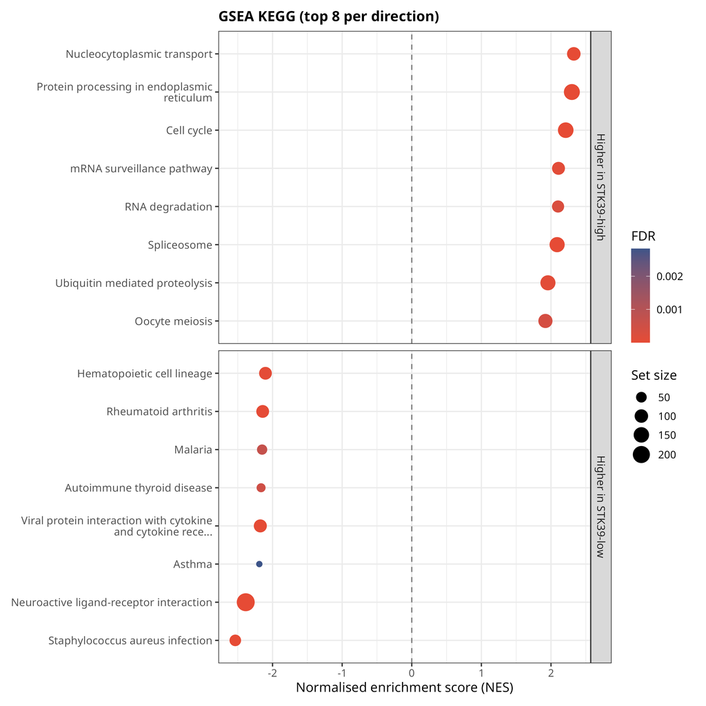

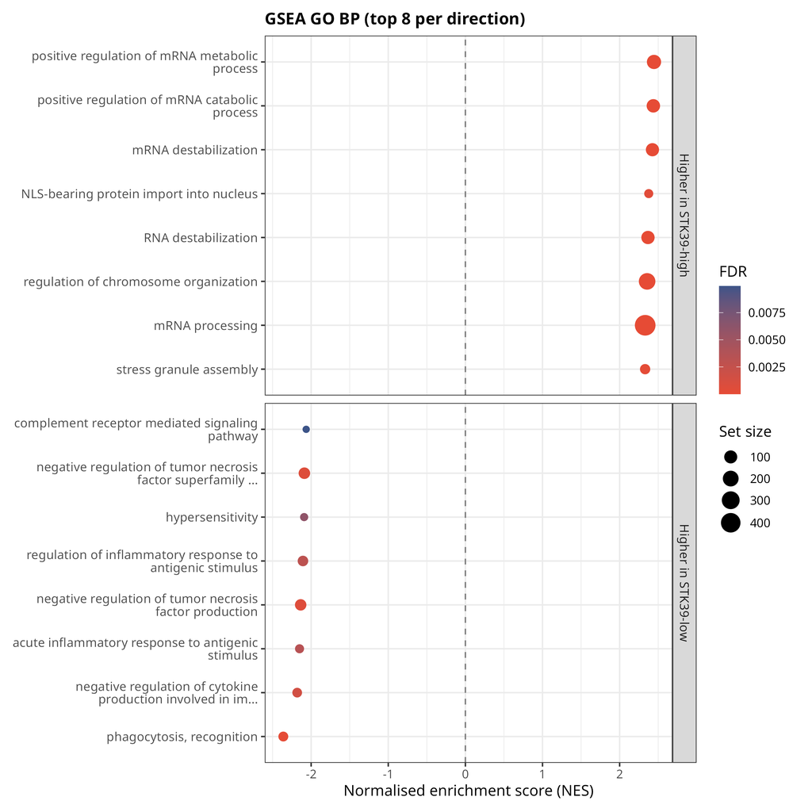

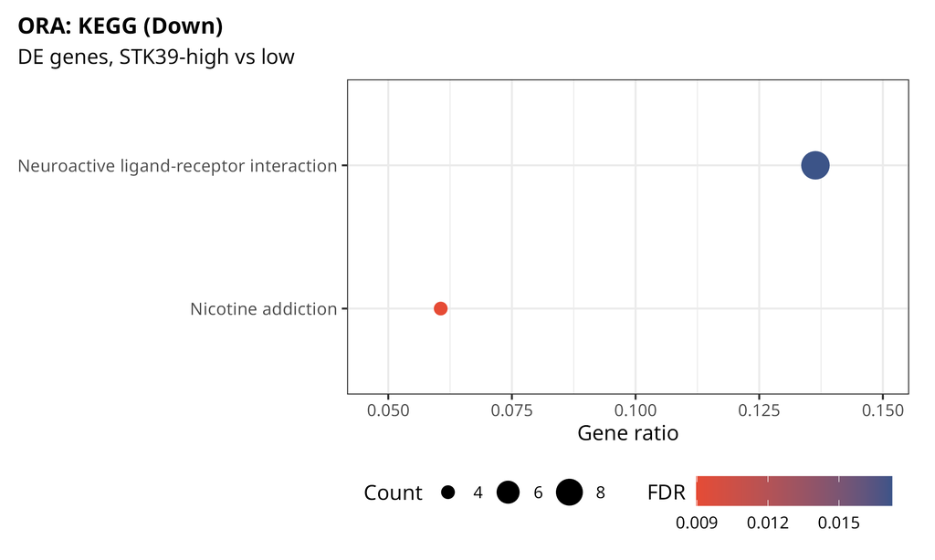

## 4. Survival (overall survival)

n = 591, 122 deaths. Log-rank (median split) p = 0.441.

Cox models (continuous = per 1 SD of log2CPM; multivariable adjusts for age, sex, stage I–II vs III–IV, COAD/READ)

|  | Model | HR | CI | p | n | events |
| --- | --- | --- | --- | --- | --- | --- |
| univariate_continuous | univariate_continuous | 0.941 | 0.784–1.13 | 0.511 | 591 | 122 |
| univariate_high_vs_low | univariate_high_vs_low | 0.870 | 0.61–1.24 | 0.441 | 591 | 122 |
| multivariable_continuous | multivariable_continuous | 0.883 | 0.737–1.06 | 0.174 | 571 | 113 |

**STK39 was not associated with OS** (proportional-hazards assumption not violated, global Schoenfeld p = 0.43). Age and stage III–IV were strong predictors, as expected.

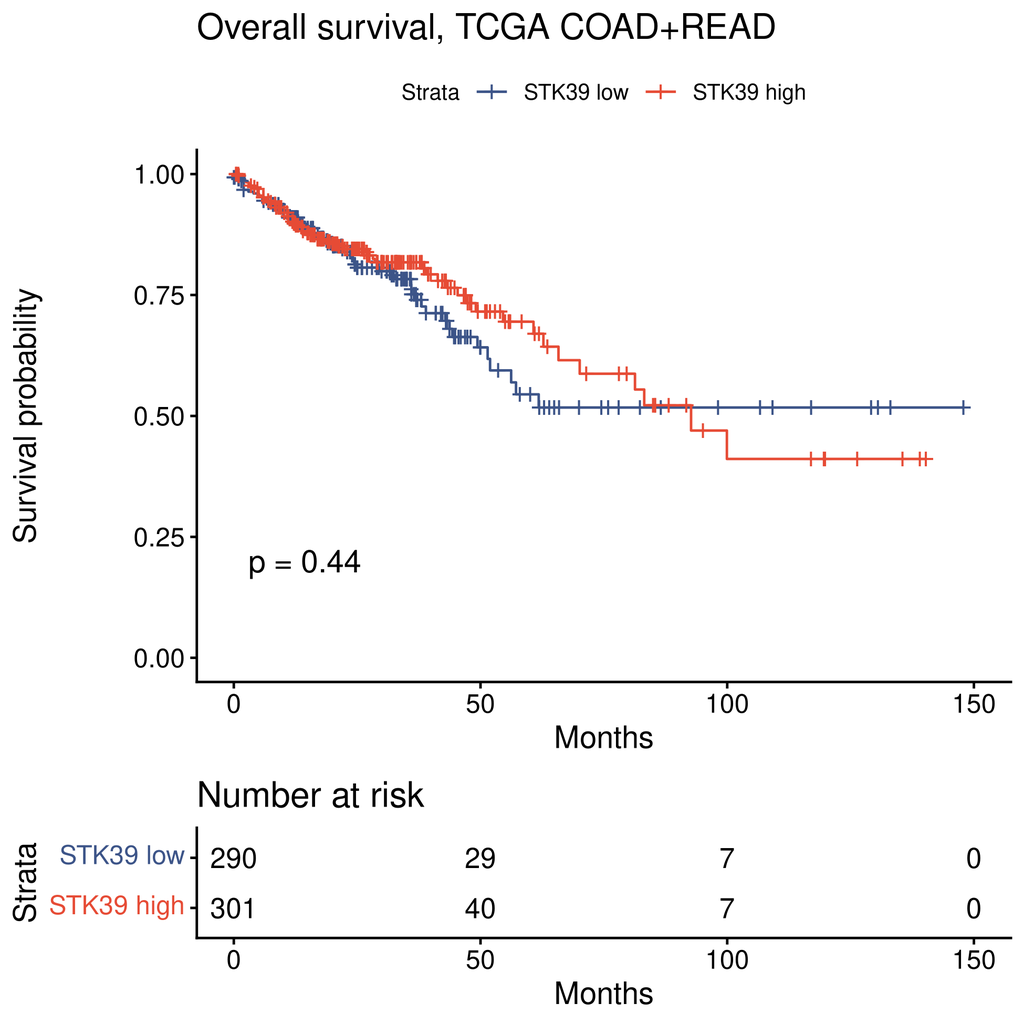

## Limitations

Only 51 normal samples (50 matched pairs); bulk RNA-seq is confounded by tumor purity and stromal/immune content, which likely drives much of the high-vs-low signal (immune programs in STK39-low); median split is arbitrary; OS has limited events and TCGA follow-up is short; no external validation cohort; associations are correlative only.

## Reproducibility

See `README.md`, `scripts/`, `sessionInfo.txt`.